# Vignette C: Create URL

# Introduction

In the previous vignettes, you will have created your customised BIO-WELL survey and linked this to your Dropbox account for remote storage of participants’ responses.

In this vignette, we will be deploying the survey onto the [Posit Shiny Server](https://posit.co/products/open-source/shinyserver/) and creating a URL to share with participants that provides access to the BIO-WELL survey.

A video walk through of this vignette can be found here on [YouTube](https://www.youtube.com/watch?v=aOExB6Ldeto).

## What is the Posit Shiny Server?

The `BIOWELL` package creates your custom BIO-WELL survey as a Shiny App. Posit Connect is a platform that can be used to publish and share Shiny Apps.

For BIO-WELL survey deployment, we will be using the cloud hosting option for [Shiny Apps](https://www.shinyapps.io/?_gl=1*1gtg1gf*_ga*MTkxOTUyMTUuMTY3NjM1NDY2OA..*_ga_2C0WZ1JHG0*MTY4NDY4NDc0NC4xNS4wLjE2ODQ2ODQ3NDQuMC4wLjA.).

Registering for an account is free. A free account allows users to deploy up to five surveys at one time, and use up to 25 active hours per month. If more active hours are needed, there are paid upgrade options available [here](https://www.shinyapps.io/?_gl=1*1qav6d0*_ga*NDMxOTk2OTM4LjE2NDk2ODgxNTk.*_ga_8PLL5FXR9M*MTY4NzI1NzkzNi4xOC4wLjE2ODcyNTc5MzguMC4wLjA.*_ga_2C0WZ1JHG0*MTY4NzI1NzkzNi41NS4wLjE2ODcyNTc5MzguMC4wLjA.#pricing-anchor).

- Free - 25 active hours ($0/month*)
- Starter - 100 active hours ($13/month*)
- Basic - 500 active hours ($49/month*)
- Standard - 2,000 active hours ($119/month*)
- Professional - 10,000 active hours($349/month*)

*Prices correct as of 20/06/2023

Active time is only counted whilst a participant is actively responding to the questions. For example, if your survey takes five minutes to complete, then 300 participants can respond to the survey each month.

# Preparation for this stage

Please ensure that you have followed the prior stages outlined in Vignette A and Vignette B. You should now have a folder for your BIO-WELL survey that contains:

1. `.secrets` folder containing your activated Dropbox access token named `dropbox_token.rds`)
2. Your custom `BIOWELL::build_survey()` input saved within an R script named `app.R`. Ensure there is no code other than this function, and that you have called the function using the double colon operator (*not* `library(BIOWELL)`)

If this is not the case, please revisit the previous vignettes before running `create_URL()`.

[figure not shown]

Your final BIO-WELL survey Shiny App folder

# Step 1: Shiny Server account

The first step is to register for a Shiny Server account via their [website](https://www.shinyapps.io/?_gl=1*1gtg1gf*_ga*MTkxOTUyMTUuMTY3NjM1NDY2OA..*_ga_2C0WZ1JHG0*MTY4NDY4NDc0NC4xNS4wLjE2ODQ2ODQ3NDQuMC4wLjA.).

[figure not shown]

Creating Shiny Server account

# Step 2: Connect your account to R

Shiny Server interacts with R through the package `rsconnect`. Install `rsconnect` and load the package library.

```r
# install.packages("rsconnect")
library(rsconnect)
library(BIOWELL)
```

On the website, click on your profile photo in the top right, and choose `Tokens` from the drop-down list. Then click to show your account’s token and secret code. Do not share your account’s secret with anyone else.

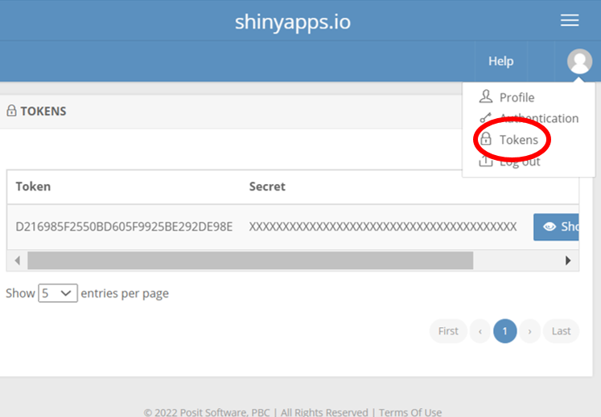

Finding Shiny Server token

This will provide code for you to run in R to connect your Shiny Server account.

```r
rsconnect::setAccountInfo(name = 'biowell-app-testing', # Your Shiny Server account username
                          token = 'string of letters and numbers', # Input your Shiny Server token number here
                          secret = 'string of letters and numbers') # Input your Shiny Server token secret here
```

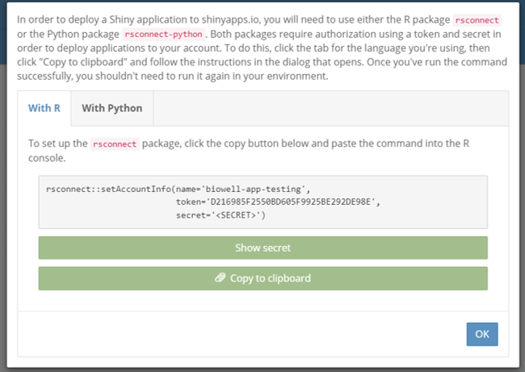

Revealing Shiny Server secret

# Step 3: Create survey URL

Now, use the `BIOWELL` package function `create_URL()` to deploy the app and retrieve a URL for sharing the survey with participants.

```r
path_to_folder <- tempdir()  # Replace with path to a local folder. e.g. "C:/Users/username/Documents/"

appName <- "my_app_name" # Replace with name for your app. Here we have kept the name of the Shiny Server app the same as the name of the local folder containing "app.R" for consistency (but it can be different if you want!)

create_URL(
  BW_app_path = paste0(path_to_folder,"/",appName),
  BW_app_name = appName,
  Shiny_Server_user = 'biowell-app-testing'
)
```

Be patient as this function will take a couple of minutes to deploy your survey on the Shiny Servers. Once completed, your browser window will open on your survey’s URL, and the URL will be printed in R.

The link is now live and can be shared with participants!

**Note: You can monitor your survey on the Posit Shiny Server dashboard.**